# act_report

## Report: WeRateDogs Insights

### Introduction

The tiwtter account WeRateDogs rates people's dogs with a humorous comment about the dog. These ratings almost always have a denominator of 10. The numerators, though? Almost always greater than 10. 11/10, 12/10, 13/10, etc. WeRateDogs has over 4 million followers and has received international media coverage. Twitters API to access this data, combined with a dataset from a neural network that predicted various dog breeds and a twitter archive file gives a great baseline to gather, assess and clean the data.The final product after the wrangling process allows analysis and visualization of insights retrieved from the data.

### Insights

#### Most common dog name

The cleaned and combined data allows insights invarious topics. One of them is the most common dog name that was used. The analysis and visualization shows that **Cooper** was the most used dog name with a total of nine. This can also be seen in the visualization below.

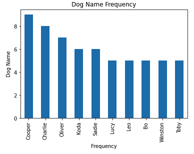

#### Dog ratings

Which dog breed has the highes mean rating numerator. The analysis shows the clumber has the highest, with a mean numerator of 27.

#### Dog stage categories

As dogs grow they undergo various stages. Those categories are Pupper, Doggo, Puppo and Doggo Pupper, with pupper being the smallest. We analyzed which category was most shared. As expected the pupper was the most shared category as you can see below.

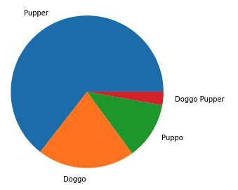

## Conclusion

There are a lot of insights that can be identified in this dataset. The Reports above just scratch on the surface. As the main focus of this project lay on the data wrangling process.